# 報告

May 08, 2018

## Hello

Progress through technology (19th century)

## h-words

- Catch each other’s attention
  - **Hey**, **Ho**: 13th century
  - **Hi**: 15th century
  - **Hollo**, **Hillo**, **Holla**, **Halloo**: 16th century
    - Shouts used in hunting
- Greetings
  - **Hal**: Be healthy
  - **Hail**: 13th century

## *Hello*

- Spelling Difference
  - Hallo, Hello, Hillo, Hollo, Hullo  
    Stress was on the second syllable, difficult to hear the quality of the first vowel.
  - Google Ngram Viewer

[interactive chart not shown]

## How *Hello* became Popular

- Early 1800s: informal, street slang
- **Telephone**
  - 1876: Invented by *Alexander Graham Bell* (Not *Edison*)
  - Need a way of starting a conversation
- **Thomas Edison**
  - Prefered Hello:  
    Shouted 'Hello' ('Halloo') into the mouthpiece when testing a phonograph (留聲機)
  - A letter (1877) used **Hello**:  
    "I don't think we shall need a call bell as 'Hello!' can be heard 10 to 20 feet away. What do you think?"

## Bell & Edison

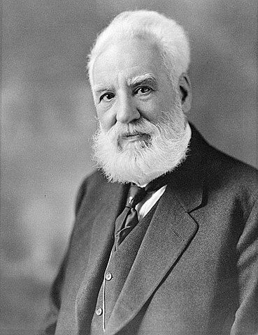

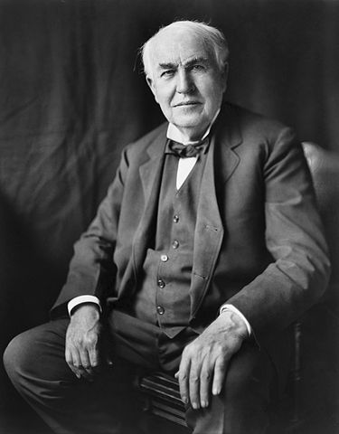

## Other Uses

- hello girls

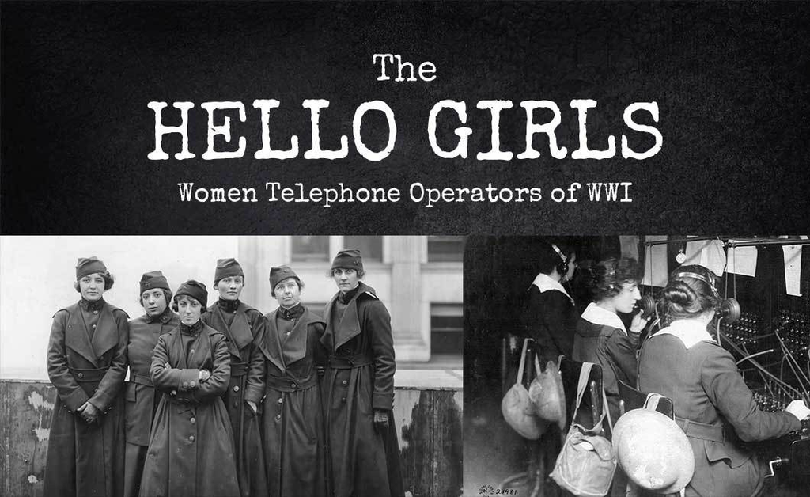

- *I mean, hello! How crazy was that?*  
  Implying that someone has missed the point in some way.

## *Hi*

- USA: 19th century
- Widely spread
- Replace Hello?
  - Common in Email
  - Easier to type than 'Hello'

[interactive chart not shown]